# 热工基础 · 第 7 讲：热辐射、换热器与总复习

刘训臣

山东科技大学 机械电子工程学院

# 第〇部分 · 课程介绍与本讲定位

- 教学内容与主线、7 次课进度表
- 本讲定位：传热学的第三块——热辐射，与传热的综合——换热器
- 光子统计 → Planck 定律 → 黑体三大定律 → 实际表面与角系数
- 全课程总复习：热力学与传热学两条主线

## 第 7 讲：教学内容与主线（一）：课时 1 热辐射

> **最后一讲：热辐射、换热器与全课程总复习。**

**课时 1 · 热辐射**

- 热辐射的本质与电磁波谱；吸收、反射与穿透
- 光子玻色子统计 → **Planck 定律**（能量密度与光谱辐射率）
- 黑体三大定律：Planck、**Wien 位移**、**Stefan–Boltzmann**
- 实际表面：Kirchhoff 定律、发射率与灰体、Lambert 余弦定律
- 角系数与两表面辐射换热、遮热板、气体辐射

## 第 7 讲：教学内容与主线（二）：课时 2 换热器与总复习

**课时 2 · 换热器与总复习**

- 传热过程：对流-导热-对流串联 → 总传热系数 $k$ 与传热热阻
- 换热器分类、顺流与逆流、**LMTD 法**与 **ε-NTU 法**、污垢热阻与强化传热
- **全课程总复习**：两条主线（热力学 / 传热学）、核心公式与考试说明

> 一句话：**第 5、6 讲给三种传热方式，本讲把它们综合成工程装置，并收束全课程。**

## 教学进度 · 7 次课全览

| 次 | 教材章 | 主题 | 课时 1 / 课时 2 |
| --- | --- | --- | --- |
| 1 | 第 1、2 章 | 基本概念、统计热力学与热力学基本定律 | 基本概念与统计力学图像 / 热力学基本定律与函数 |
| 2 | 第 3 章 | 理想气体与热力过程 | 理想气体（状态方程、内能、熵） / 热力过程与 Carnot 循环 |
| 3 | 第 4、5 章 | 气体混合、水蒸汽、湿空气与气体流动 | 气体混合物、水蒸汽与湿空气 / 气体流动与喷管 |
| 4 | 第 6、7 章 | 压气机与动力循环、制冷循环 | 压气机与气体动力循环 / 蒸汽动力循环与制冷循环 |
| 5 | 第 8、9 章 | 导热 | 三种传热方式与 Fourier 导热定律 / 稳态导热与热阻分析 |
| 6 | 第 10 章 | 对流换热 | 对流机理与边界层、准则数 / 准则关联式及其应用 |
| **7** | **第 11、12 章** | **热辐射、换热器与总复习** | **热辐射基本定律与辐射换热计算 / 换热器与全课程总复习** |

## 本讲在课程中的位置（一）

**第 5、6 讲讲了两种传热方式**：

- 导热：Fourier 定律 $q=-\lambda\,dT/dx$，靠**分子碰撞/晶格振动**，需介质
- 对流换热：Newton 冷却定律 $q=h\,\Delta T$，靠**流体宏观运动**，需介质

**本讲讲第三种**——**热辐射**：

- 靠**电磁波**传热，**真空中也能传热**（太阳照地球就是）
- 换热量 ∝ **$T^4$**（不是一次温差），高温下急剧主导
- 源头是**光子统计**：Planck 定律 → 黑体三大定律

> 之后把三种方式**串联**成一个工程装置——**换热器**，并做全课程总复习。

## 本讲定位（二）：推导留给 AI

**本讲的两条主线**：

1. **从统计到定律**：光子是玻色子 → 光子数极值分布 → Planck 定律 →（求极值得）Wien 位移、（全波长积分的）Stefan–Boltzmann——这是全课程**第三次**把统计力学落到具体物理量上（前两次：理想气体、化学平衡）
2. **从方式到装置**：导热 + 对流 + 辐射 → 串联热阻 → 总传热系数 → 换热器设计（LMTD / ε-NTU）

**推导留给 AI**：① 让他说明”光子数不守恒 ⇒ 化学势为零 ⇒ Bose 分布分母是 $-1$“这条链；② 问他 Planck 定律的两个极限（低频 Rayleigh–Jeans、高频 Wien 近似）各是什么形式；③ 问：为什么换热器设计要用对数平均温差而不是算术平均？

# 第一部分 · 热辐射的本质与 Planck 定律

- 热辐射与电磁波谱：热效应的波谱范围
- 吸收、反射与穿透；黑体、白体、镜体、透明体、灰体
- 光子玻色子统计 → 光子数极值分布
- Planck 定律：能量密度、光谱辐射率与两个极限

## 热辐射与电磁波谱

**热辐射**：物体因自身温度而向外发射电磁波的现象；**辐射换热**：物体间以热辐射方式交换热量。

- 电磁波传播速率与波长、频率的关系：$c=\lambda\nu$
- **热效应的波谱范围**：$0.1$–$1000\ \mu\text{m}$；工业温度（<2000 K）：$0.38$–$100\ \mu\text{m}$，大部分在红外（$0.76$–$20\ \mu\text{m}$）
- **太阳辐射**（$0.2$–$3\ \mu\text{m}$）：紫外 $0.30$–$0.38\ \mu\text{m}$ 约 7%；可见光 $0.38$–$0.76\ \mu\text{m}$ 约 45%；红外 $0.76$–$3.0\ \mu\text{m}$ 约 48%

> 与导热、对流的本质区别：辐射**不需要介质**，且在真空中效率最高。

## 吸收、反射与穿透

物体对外来辐射的总能量 $Q$ 分为三部分：**吸收** $Q_\alpha$、**反射** $Q_\rho$、**穿透** $Q_\tau$：

$$\alpha+\rho+\tau=1$$

- **光谱吸收比** $\alpha_\lambda$、**光谱反射比** $\rho_\lambda$、**光谱透射比** $\tau_\lambda$：对单色辐射的三个比
- 三参数都是 $0$–$1$ 之间的无量纲量，且 $\alpha_\lambda+\rho_\lambda+\tau_\lambda=1$

## 理想物体：黑体、白体、镜体、透明体、灰体

按”哪个参数取 1”定义五种理想物体：

- **黑体**：吸收比 $\alpha=1$（吸收一切辐射）
- **白体**：反射比 $\rho=1$ 且**漫反射**
- **镜体**：反射比 $\rho=1$ 且**镜面反射**
- **透明体**：穿透比 $\tau=1$
- **灰体**：**光谱特性参数不随波长变化**（真题考点）

> 黑体是辐射计算的**基准**：同温度下它的吸收能力与辐射能力都最强。

## 辐射力与光谱辐射力

- **辐射力** $E$：单位时间内单位面积表面向**半球空间**发射的全部波长辐射能，单位 $\text{W/m}^2$
- **光谱辐射力** $E_\lambda$：某一波长 $\lambda$ 附近单位波长的辐射力，单位 $\text{W}/(\text{m}^2\cdot\mu\text{m})$

$$E=\int_0^\infty E_\lambda\,d\lambda$$

- 辐射力是**离开表面**的量（发射）；吸收/反射/穿透是**落在表面**的量（接收）

## 玻色子与光子

- 玻色子：**对称**波函数，同一能级布局数**不受限**
- 费米子：反对称波函数，泡利不相容（布局数 1）
- 光子自旋为 1，属于**玻色子**，服从 Bose–Einstein 统计

| 粒子种类 | 波函数对称性 | 能级布局数 | 例 | 统计分布 |
| --- | --- | --- | --- | --- |
| 费米子 | 反对称 | 1 | e、D、He³ | Fermi–Dirac |
| 玻色子 | 对称 | ∞ | 光子、H、He⁴ | Bose–Einstein |

## 光子数分布：极值分布

高能级布局数少但**简并度高** → 光子数随能量出现**极值分布**：

$$\frac{dN}{V} = \frac{8\pi \nu^2}{c^3}\frac{1}{e^{\beta h\nu}-1}\,d\nu$$

- 态密度 $8\pi\nu^2/c^3$（偏振 2 × 立体角 $4\pi$ × 频率平方）：随频率**增大**
- Bose 因子 $1/(e^{\beta h\nu}-1)$：随能量**减小**
- 两者相乘 ⇒ 中间频率出现**峰值**——黑体辐射谱的钟形曲线

## Planck 定律：能量密度

单位频率下光场的能量分布：

$$u_\nu = h\nu\frac{dN}{V} = \frac{8\pi h\nu^3}{c^3}\frac{1}{e^{\beta h\nu}-1}$$

单位：$\text{J}\cdot\text{m}^{-3}\cdot\text{Hz}^{-1}$（能量密度 = 单光子能量 × 单位频率光子数）。

## Planck 定律：光谱辐射率

写成长度（波长）与辐射率的形式：

$$B_\lambda = \frac{2hc^2}{\lambda^5}\frac{1}{e^{hc/\lambda k_BT}-1}$$

大平面的光谱辐射力（Lambert 表面，$E_\lambda=\pi B_\lambda$）：

$$E_\lambda = \pi B_\lambda = \frac{2\pi hc^2}{\lambda^5}\frac{1}{e^{hc/\lambda k_BT}-1}$$

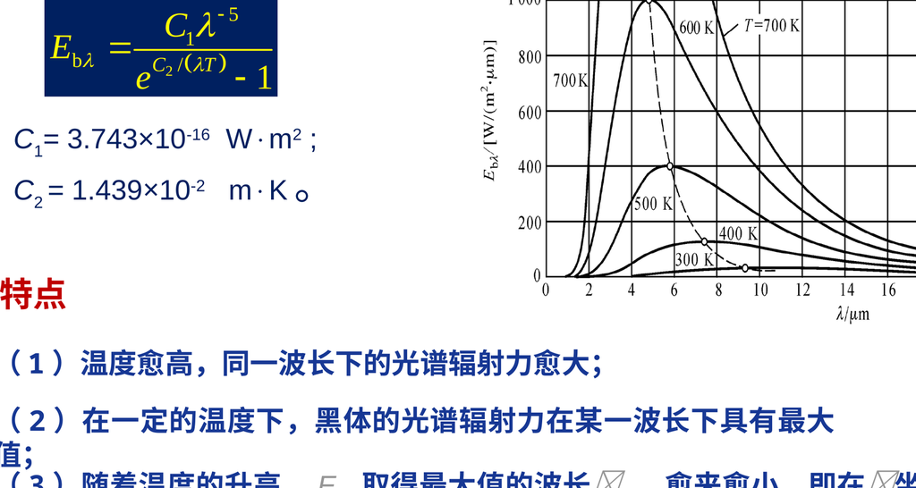

不同温度下黑体光谱辐射力：温度愈高曲线整体愈高，峰值向短波移动

## 两个极限：Rayleigh–Jeans 与 Wien 近似

- **低频极限**（$hc\ll\lambda k_BT$）：$e^x-1\to x$ ⇒ **Rayleigh–Jeans 定律** $E_\lambda=\dfrac{2\pi c k_BT}{\lambda^4}$
- **高频极限**（$hc\gg\lambda k_BT$）：$e^x-1\to e^x$ ⇒ **Wien 近似** $E_\lambda=\dfrac{2\pi hc^2}{\lambda^5}e^{-hc/\lambda k_BT}$

> 1900 年 Planck 正是在两式之间**插值**得到完整定律，开启了量子论；Rayleigh–Jeans 的”紫外灾难”正是经典物理失败的标志。

## 第一、第二辐射常数

$$c_{1L} = 2hc^2, \qquad c_1 = 2\pi hc^2, \qquad c_2 = \frac{hc}{k_B}$$

- $c_{1L}=2hc^2$：**光谱辐射率**用的第一辐射常数
- $c_1=2\pi hc^2$：**光谱辐射力**用的第一辐射常数（相差因子 $\pi$）
- $c_2=hc/k_B$：第二辐射常数（两者通用，也出现在 Wien 位移定律）

$$c_1=3.742\times10^{-16}\ \text{W}\cdot\text{m}^2, \qquad c_2=1.439\times10^{-2}\ \text{m}\cdot\text{K}$$

## 思考与提问 · 热辐射的本质

> **开放性问题**（没有唯一答案）：先自己想，再让 AI 帮你查证、找反例。
1. 辐射传热不需要介质。请让 AI 说明：热辐射与无线电波、X 射线本质上有何异同？为什么只有 $0.1$–$1000\ \mu\text{m}$ 的波段被称为”热辐射”？
2. 光子数不守恒 ⇒ 化学势为零。请说明这个推理的每一步，并让 AI 举出**另一个**”数不守恒 ⇒ μ=0”的物理体系（提示：声子）。
3. “紫外灾难”是量子论的起点。请让 AI 讲清 Rayleigh–Jeans 定律为什么会发散，并判断它说得对不对。

# 第二部分 · 黑体辐射定律与实际表面

- Wien 位移定律与 Stefan–Boltzmann 定律
- Kirchhoff 定律：发射率 = 吸收比
- 发射率与灰体近似、Lambert 余弦定律
- 角系数：定义、三性质与代数分析计算

## Wien 位移定律

光谱辐射力极值位置由

$$\frac{xe^x}{e^x-1}-5 = 0, \qquad x = 4.965114\ldots$$

给出：

$$\lambda_{max} = \frac{c_2}{xT} \approx \frac{2898\ \mu\text{m}\cdot\text{K}}{T}$$

- 温度越高，峰值越向**短波**方向移动
- 太阳 $5800$ K：$\lambda_{max}\approx0.5\ \mu\text{m}$（可见光，可见光占太阳辐射能约 45%）；$2000$ K：$\lambda_{max}\approx1.45\ \mu\text{m}$（红外）

## Stefan–Boltzmann 定律

对 Planck 定律全波长积分（用 $\int_0^\infty\frac{x^3}{e^x-1}dx=\frac{\pi^4}{15}$）：

$$\sigma = \frac{2\pi^5k_B^4}{15c^2h^3} = \frac{\pi^2k_B^4}{60\hbar^3c^2}, \qquad E_b = \sigma T^4$$

$$\sigma = 5.67\times10^{-8}\ \text{W}/(\text{m}^2\cdot\text{K}^4)$$

- 黑体辐射力与温度**四次方**成正比（“四次方定律”，真题高频）
- 高温下辐射急剧主导：锅炉、炼钢与燃烧火焰中辐射换热占统治地位

## Kirchhoff 定律

**热平衡下，任何物体的发射率等于其对同温度黑体辐射的吸收比**：

$$\varepsilon = \alpha \qquad(\text{热平衡})$$

- 物理解读：**好吸收的物体必然好辐射**（反之亦然）
- 推论：同温度下黑体的辐射力最大（$E_b$ 是上限，实际表面 $E=\varepsilon E_b<E_b$）
- 工程例子：锅底涂黑（提高吸收/发射）；保温瓶内胆镀银（降低发射）

## 发射率与灰体近似

- 黑体：$\varepsilon = 1$，辐射力 $E_b = \sigma T^4$
- 实际表面发射率 $\varepsilon < 1$，**灰体近似**：

$$E = \varepsilon\sigma T^4$$

- 灰体：**光谱特性参数不随波长变化**（真题考点）
- 工程典型值：抛光金属 $\varepsilon\approx0.05$；氧化表面 $\varepsilon\approx0.8$

## Lambert 余弦定律

**漫射表面**（Lambert 表面）：辐射强度（单位立体角、单位投影面积）与方向无关：

$$E = \pi I \qquad(\text{光谱形式：}E_\lambda=\pi I_\lambda)$$

- 按 $\cos\theta$ 分布：与法线成 $\theta$ 角方向的辐射通量 $\propto I\cos\theta$（“余弦定律”）
- 白体是典型的漫射表面；工程表面多数近似 Lambert
- **意义**：Lambert 表面下 $E_\lambda=\pi B_\lambda$，且角系数成为**纯几何量**

## 角系数：定义

**辐射角系数** $X_{1,2}$：从表面 1 发出的总辐射能中**直接**投射到表面 2 上的份额。

- 符号：本课用 $F_{ij}$（教材记 $X_{1,2}$，同一概念）
- 只计”直接”投射（不经第三面反射）
- 当表面辐射符合 **Lambert 定律**时，角系数是**纯几何参数**——与温度、发射率无关

## 角系数的三个性质

- **相对性（互易性）**：$A_iF_{ij} = A_jF_{ji}$（互换面积相等）
- **完整性**：$\sum_j F_{ij} = 1$（对封闭腔所有表面求和）
- **可加性（分解性）**：$F_{i,(j_1+j_2)} = F_{ij_1} + F_{ij_2}$

## 角系数的计算：代数分析法

利用三性质**解方程**求角系数（常用几何构型）：

- 平行大平板、无限长同心圆柱等：$X_{1,2}=1$
- **三个非凹表面构成的封闭空腔**：解方程组得

$$X_{1,2}=\frac{A_1+A_2-A_3}{2A_1}$$

- 一般构型：查表（教材附角系数图表）

## 思考与提问 · 黑体定律与实际表面

> **开放性问题**（没有唯一答案）：先自己想，再让 AI 帮你查证、找反例。
1. Kirchhoff 定律说”好吸收=好辐射”。请让 AI 说明：为什么违反这一定律就能造出**第二类永动机**？把论证链写完整。
2. Lambert 余弦定律是”角系数为纯几何量”的前提。请找出**一个**表面不满足 Lambert 定律的真实例子，并说明此时角系数为何失效。
3. 灰体是理想化。请让 AI 说明实际材料（如铝、玻璃、氧化铁）的光谱发射率如何随波长变化，并判断工程上用灰体近似的误差来源。

# 第三部分 · 辐射换热计算

- 两表面间辐射换热的计算式
- 两平行大平板的系统发射率与遮热板
- 气体辐射的特点
- 辐射换热的强化与削弱

## 两表面间辐射换热：简化式

灰体近似下两表面间净辐射换热（角系数 $F=1$ 的典型情况）：

$$E_{12} = \varepsilon\sigma\left(T_1^4 - T_2^4\right)$$

- 净换热 ∝ $\sigma(T_1^4-T_2^4)$：“高温四次方 − 低温四次方”
- $F=1$ 的典型构型：平行大平板、被包表面接近黑体
- 物理图像：辐射换热是**四次方温差**，高温下主导传热

## 两平行大平板：系统发射率

两灰体大平板之间的辐射换热（一般式，含两侧发射率）：

$$Q = \frac{\sigma A\left(T_1^4-T_2^4\right)}{\dfrac{1}{\varepsilon_1}+\dfrac{1}{\varepsilon_2}-1}$$

- 分母是”**系统发射率**”的倒数：$\varepsilon_s=\left(\dfrac{1}{\varepsilon_1}+\dfrac{1}{\varepsilon_2}-1\right)^{-1}$
- 两侧都 $\varepsilon\to1$ 时回到黑体式 $Q=\sigma A(T_1^4-T_2^4)$
- 发射率越低，换热被削弱越多

**算例**：$T_1=500$ K、$T_2=300$ K、$\varepsilon_1=\varepsilon_2=0.8$：

$$Q = \frac{5.67\times10^{-8}\times\left(500^4-300^4\right)}{\frac{1}{0.8}+\frac{1}{0.8}-1}\approx2060\ \text{W/m}^2$$

## 遮热板（辐射屏）

在两表面间插入**遮热板**（辐射屏）：串联多个”辐射热阻”，削弱辐射换热。

$$Q_{\text{有屏}} = \frac{1}{n+1}\,Q_{\text{无屏}} \qquad(n\ \text{块屏},\ \text{同}\ \varepsilon)$$

- 机理：屏的中间温度介于 $T_1$、$T_2$ 之间，两次换热各按更小的温差进行
- 应用：保温瓶双层镀银壁、航天器**多层隔热**（几十层镀铝薄膜）

## 气体与火焰辐射

- 气体对辐射的吸收与发射具有**选择性**：分立谱线/谱带，与分子能级跃迁对应
- 与分子转动、振动、电子能级对应；CO₂、H₂O 蒸气在红外有强吸收带（温室效应的物理基础）
- 是燃烧诊断与激光诊断课程的基础

## 辐射换热的强化与削弱

**削弱**（保温、隔热）：

- 遮热板 / 多层隔热（最有效）
- 低发射率表面：抛光、镀银（保温瓶内胆）

**强化**（散热、吸热）：

- 高发射率表面：涂黑、氧化、粗糙化
- 提高温度差、增大角系数（减小距离、增加面积）
- 太阳集热器用**选择性吸收涂层**：可见光波段吸收强、红外波段发射弱

# 第四部分 · 传热过程与换热器

- 复合传热与总传热系数、传热热阻构成
- 换热器分类与顺流、逆流
- 对数平均温差（LMTD）法与 ε-NTU 法
- 污垢热阻与强化传热

## 传热过程：三种方式接力

**传热过程**：热流体通过固体壁把热量传给冷流体的完整路径——对流-导热-对流三种基本方式的串联：

- 热流体 → 壁面：**对流换热**
- 壁内：**导热**
- 壁面 → 冷流体：**对流换热**

$$\text{热阻串联：}\quad R = R_{h1} + R_\lambda + R_{h2}$$

## 总传热系数 k

多层热阻串联（对流-导热-对流）：

$$\frac{1}{kA} = \frac{1}{h_1A} + \frac{\delta}{\lambda A} + \frac{1}{h_2A}, \qquad Q = kA\,\Delta T$$

- $k$：总传热系数，单位 $\text{W}/(\text{m}^2\cdot\text{K})$；$1/(kA)$：总传热热阻
- $k$ 由两侧对流换热系数 $h_1$、$h_2$ 与壁导热 $\lambda/\delta$ 共同决定
- 一侧 $h$ 很小（如**气侧**）则该侧热阻主导——强化换热的”短板”

## 换热器分类

**间壁式换热器**（冷热流体被壁隔开）主要类型：

- **套管式**：结构简单，可顺流/逆流
- **管壳式**：工业主流，壳程加折流板强化换热
- **交叉流**：两流体流动方向垂直（汽车散热器）
- **板式**：紧凑、易清洗，适用于液-液
- **翅片管式**：强化**气侧**换热；**板翅式 / 螺旋板式**：结构紧凑

## 顺流与逆流

- **顺流**：冷热流体同向流动，沿程温差衰减快，$\Delta T_{lm}$ 较小
- **逆流**：冷热流体反向流动，$\Delta T_{lm}$ 较大
- 相同进口温度、流量与面积下，**逆流传热量更大**；逆流可使冷流体出口温度**超过**热流体出口温度（顺流做不到）
- 流动型式影响出口温度、换热温差、换热量与温度分布

## 对数平均温差（LMTD）

冷热流体沿程温差变化，需取**对数平均**：

$$\Delta T_{lm} = \frac{\Delta T_1 - \Delta T_2}{\ln(\Delta T_1/\Delta T_2)}, \qquad Q = kA\,\Delta T_{lm}$$

- $\Delta T_1$、$\Delta T_2$：换热器**两端**的温差
- 推导：对微元 $dA$ 写 $dQ=k(T_h-T_c)\,dA=-c_p\dot m\,dT$，沿程积分即得
- 当 $\Delta T_1\approx\Delta T_2$ 时对数平均退化为**算术平均**

## ε-NTU 法

当**出口温度未知**（设计校核型问题）时用效能-传热单元数法：

$$\varepsilon = \frac{Q}{Q_{max}} = \frac{|\Delta T|_{\text{max侧}}}{T_{h,in}-T_{c,in}}, \qquad NTU = \frac{kA}{C_{min}}, \qquad C_r = \frac{C_{min}}{C_{max}}$$

- 逆流（$C_r<1$）：

$$\varepsilon = \frac{1-e^{-NTU(1-C_r)}}{1-C_r\,e^{-NTU(1-C_r)}}$$

- $C_r\to1$（两侧热容量相等）时：$\varepsilon = \dfrac{NTU}{1+NTU}$
- **算例**：$NTU=2$、$C_r=0.5$ → $\varepsilon=0.775$；$C_r=1$ → $\varepsilon=0.667$（Python 复核 ✓）

## 污垢热阻与强化传热

**污垢热阻**：运行中壁面结垢（水垢、油污）使 $k$ 显著下降：

$$\frac{1}{k} = \frac{1}{h_1} + \frac{\delta}{\lambda} + \frac{1}{h_2} + R_{f,1} + R_{f,2}$$

- 换热器需**定期清洗**；设计时预留污垢热阻

**强化传热**：针对最大热阻一侧：

- 加大换热面积（**翅片**）、增加流体扰动（折流板、螺旋管）
- 提高流速（代价：泵功增大）、清除污垢

## 思考与提问 · 传热过程与换热器

1. 逆流的 $\Delta T_{lm}$ 恒不小于顺流。请让 AI 证明这一点，并说明顺流在什么场合反而更合适。
2. 请让 AI 推一遍 LMTD 的沿程积分，判断它每一步的符号（热流体放热、冷流体吸热）是否与你一致。
3. ε-NTU 与 LMTD 两种方法各适合什么问题？请用”已知条件不同”的语言重述，并让 AI 举一个各自的工程例子。

# 第五部分 · 例题与真题

- 辐射换热真题（黑体、辐射力、灰体、角系数）
- 传热过程真题（对流换热辨析）
- 典型算例：Wien、平行平板、遮热板、LMTD
- 全部答案经 Python 独立复核

## 课堂例题 1：黑体（真题）

**判断**：相同温度下，辐射能力和吸收能力最强的理想物体是黑体。（2025—2026 学年 A 卷）

**参考答案**：正确。

- 黑体吸收比 $\alpha = 1$，辐射能力 $E_b = \sigma T^4$ 在同温度下最大

## 课堂例题 2：辐射力表达式与理想物体（真题）

**简答**：写出黑体辐射力的表达式；黑体、白体和透明体这三种理想物体定义的依据分别是什么？（2025—2026 学年 A 卷 / 2024—2025 春 B 卷）

**参考答案**：

$$E_b = \sigma T^4, \qquad \sigma = 5.67\times10^{-8}\ \text{W/(m}^2\cdot\text{K}^4\text{)}$$

- 黑体：吸收比 $\alpha = 1$（吸收一切辐射）
- 白体：反射比 $\rho = 1$（漫反射）
- 透明体：穿透比 $\tau = 1$（全部透射）

## 课堂例题 3：灰体与角系数性质（真题）

**简答**：

1. 光谱特性参数不随波长变化的理想物体称为？（2025—2026 学年 B 卷填空）→ **灰体**
2. 写出角系数的三种性质。（2024—2025 春 A 卷）→ **相对性（互易）$A_1F_{12}=A_2F_{21}$、完整性 $\sum F_{1j}=1$、可加性**

## 课堂例题 4：角系数可加性（真题）

**判断**：辐射角系数不具有可加性。（2025—2026 学年 A 卷）

**参考答案**：错误。

- 角系数具有**可加性**（分解性），是角系数的三种基本性质之一
- $F_{i,(j_1+j_2)} = F_{ij_1} + F_{ij_2}$

## 课堂例题 5：对流换热定义（真题）

**判断**：流体与所接触的固体壁面之间的热量交换称之为热对流。（2025—2026 学年 A 卷）

**参考答案**：错误。

- 应为**对流换热**（流体与壁面间换热，含热对流与导热）
- 热对流仅指流体宏观运动携带热量的传热方式

## 典型算例 1：Wien 位移（太阳测温）

**题**：测得太阳表面辐射峰值波长约 $0.5\ \mu\text{m}$，求表面温度；室温 $300$ K 物体的峰值波长是多少？

**解**：

$$T = \frac{2898\ \mu\text{m}\cdot\text{K}}{0.5\ \mu\text{m}} \approx 5800\ \text{K};\qquad
\lambda_{max} = \frac{2898}{300} = 9.7\ \mu\text{m}\ (\text{红外})$$

- 红外测温、天文光谱定温的原理：**测出峰值位置即测出温度**
- 复核：$2898/5800=0.4997\ \mu\text{m}$；$2898/300=9.66\ \mu\text{m}$ ✓（Python）

## 典型算例 2：两平行大平板辐射换热

**题**：两平行大平板 $T_1=500$ K、$T_2=300$ K，$\varepsilon_1=\varepsilon_2=0.8$，求单位面积净辐射换热量。

**解**：

$$\frac{q}{\sigma(T_1^4-T_2^4)} = \left(\frac{1}{0.8}+\frac{1}{0.8}-1\right)^{-1}=0.667
\ \Rightarrow\ q=0.667\times5.67\times10^{-8}\times(500^4-300^4)\approx2060\ \text{W/m}^2$$

- 复核（Python）：$\sigma T_1^4=3544$、$\sigma T_2^4=459$ W/m²，$q=2056$ W/m² ✓
- 若两侧都是黑体（$\varepsilon=1$）：$q=3085$ W/m²（系统发射率 = 1）

## 典型算例 3：遮热板减半

**题**：续上题，在中间插入 1 块同发射率（$\varepsilon=0.8$）的遮热板，净辐射换热变为多少？

**解**：

$$Q_{\text{有屏}} = \frac{1}{2}Q_{\text{无屏}} \approx 1030\ \text{W/m}^2$$

- 复核（Python）：$2056/2=1028$ W/m² ✓
- 屏的稳态温度：$T_s^4=\dfrac{T_1^4+T_2^4}{2}$，代入得 $T_s\approx433$ K

## 典型算例 4：LMTD 顺流与逆流

**题**：换热器中热流体 $100\to70$ ℃、冷流体 $30\to60$ ℃。求顺流与逆流的 $\Delta T_{lm}$；若 $k=100$ W/(m²·K)、$A=10$ m²，求逆流换热量。

**解**：

| 布置 | 两端温差 | $\Delta T_{lm}$ |
| --- | --- | --- |
| 顺流 | $70$ / $10$ K | $\dfrac{70-10}{\ln 7}=30.8$ K |
| 逆流 | $40$ / $40$ K | $40$ K（算术平均） |

$$Q = kA\Delta T_{lm} = 100\times10\times40 = 40\ \text{kW}$$

- 复核（Python）：顺流 30.83 K、逆流 40.00 K ✓

# 第六部分 · 全课程总复习与作业

- 全课程两条主线（热力学 / 传热学）
- 复习要点、考试范围与题型说明
- 课程总结表（7 讲核心公式）
- 作业：计算题 4 道 + 思考题 3 道

## 全课程知识主线

1. **微观**：原子假说 → 量子能级 → 统计分布 → 熵与配分函数
2. **宏观**：热力学公设 → 第一/第二定律 → 热力学函数
3. **工质**：理想气体 → 热力过程 → Carnot 循环
4. **化学与相变**：JANAF、化学平衡、水蒸气与湿空气
5. **流动与装置**：马赫数、喷管、动力与制冷循环
6. **传热**：导热 → 对流 → 辐射 → 换热器

## 复习要点

- 公式从配分函数、热力学函数或守恒方程**推导**
- 典型计算：理想气体过程、Carnot 效率、喷管流量、稳态导热、LMTD
- 图表工具：T-s 图、Mollier 图、焓湿图、JANAF 表

## 考试提示

- 概念题重点：熵增、可逆性、$Ma$ 划分、无量纲数物理意义
- 计算题注意单位与状态点
- 传热计算先画热阻串联，再套 $Q = kA\Delta T$ / $\Delta T_{lm}$
- 辐射题：黑体 $E_b=\sigma T^4$、灰体 $E=\varepsilon\sigma T^4$、角系数三性质

## 课程总结（一）：第 1–4 讲

[output not shown]

## 课程总结（二）：第 5–7 讲

| 讲次 · 主题 | 核心公式与概念 |
| --- | --- |
| 5 · 导热 | $q=-\lambda\,dT/dx$，稳态导热热阻串联 |
| 6 · 对流换热 | $q=h\Delta T$，$Nu$、$Re$、$Pr$、$Gr$ |
| 7 · 辐射与换热器 | $E_b=\sigma T^4$，$\lambda_{max}T\approx2898\ \mu\text{m·K}$，角系数，$1/(kA)$，LMTD |

## 讲义思考题与习题（一）

> 出处：教材书稿 `book/chapters/ch06.qmd`「习题与思考」段，完整收录。
1. 从光子玻色子统计出发推导 Planck 定律，说明 Wien 位移定律与 Stefan–Boltzmann 定律的由来。
2. 说明发射率、灰体与角系数的定义及辐射换热计算中各自的用途。
3. 推导多层平壁的总传热系数，说明热阻串联的意义。
4. 比较顺流与逆流换热器的 $\Delta T_{lm}$ 与换热效果。

## 讲义思考题与习题（二）

5. 画出全课程的知识主线，说明统计热力学、宏观热力学与传热学之间的联系。
6. 估算太阳表面 5777 K 的辐射峰值波长；用 Stefan–Boltzmann 定律比较 1000 K 与 300 K 黑体辐射力之比。
7. 由 $dQ = k\,\Delta T\,dA$ 沿程积分推导对数平均温差公式。

## 作业（本讲）：计算题 4 道

1. **Wien 位移**：估算太阳表面 5777 K 的辐射峰值波长；比较 1000 K 与 300 K 黑体的辐射力之比。（答案：$0.50\ \mu\text{m}$；$(10/3)^4\approx123$）
2. **平行平板辐射**：两平行大平板 $T_1=500$ K、$T_2=300$ K、$\varepsilon=0.8$，求单位面积净辐射换热量。（答案：$2060\ \text{W/m}^2$）
3. **遮热板**：续上题插入 1 块同发射率遮热板，求换热量与屏的稳态温度。（答案：$1030\ \text{W/m}^2$；$T_s\approx433$ K）
4. **LMTD**：换热器热流体 $100\to70$ ℃、冷流体 $30\to60$ ℃，求顺流与逆流的 $\Delta T_{lm}$；$k=100$ W/(m²·K)、$A=10$ m² 时逆流换热量。（答案：$30.8$ K / $40$ K；$40$ kW）

## 作业（本讲）：思考题 3 道

5. **为什么辐射不需要介质**：热辐射与导热、对流在”传热机制”上的本质区别是什么？说明真空中的太阳辐射如何到达地球。
6. **Kirchhoff 定律**：解释”好吸收的物体必然好辐射”，并举两个工程上利用（或规避）这一性质的例子。
7. **两种设计方法**：LMTD 法与 ε-NTU 法各适用于什么场合？各举一个工程例子。

## 本讲小结

- **辐射**：光子玻色子统计 → Planck 定律 → Wien 位移 + Stefan–Boltzmann
- **表面**：Kirchhoff 定律、发射率 ε、灰体近似、Lambert 余弦定律、角系数（互易/完整/可加）
- **计算**：系统发射率、遮热板、气体辐射、辐射强化与削弱
- **换热器**：对流-导热-对流串联 → $1/(kA)$ → $Q = kA\Delta T_{lm}$；LMTD 与 ε-NTU
- **复习**：全课程两条主线，公式靠推导、图表靠会用

## 结课

> 热力学与统计物理是统一的，传热学是热力学在工程中的应用。

谢谢大家！